# Stock_price_2024

## Stock Market Analysis of Various Companies Using Python

**Business Scenario:** Data Science extracts meaningful insight from chunks of raw data, which is useful to different business segments for planning their future course of action. Finance is probably one of the first to catch on to this trend with a rise in the penetration of analytics into many aspects of our lives. Here, we will analyze data from the stock market for some technology stocks such as Apple, Google, Amazon, and Microsoft.

**Goal:** I'm going to extract and analyze the information, visualize it, and look at different ways to analyze the risk of a stock, based on its performance history using Python libraries such as Pandas, Seaborn, and Matplotlib.

**About the Data:** The stocks chosen for analysis:

- Apple
- Google
- Microsoft
- Amazon

For the start, we shall investigate the Amazon stock individually and then move on to the combined analysis.

**Source used for the stocks data: https://in.finance.yahoo.com/**

My work consists of the following tasks:

- Reading the Data from Yahoo finance website directly.
- Performing cleaning.
- Studying the change in stock price over time
- Visualizing the change in a stock’s volume being traded, over time
- Moving average of various stocks
- Daily return average of a stock
- Checking the Trend based on Daily Return.
- Visualizing trend frequency through a Pie Chart.
- Studying correlation between the daily returns of different stocks

#### Amazon Stock Data

```python
import numpy as np
import pandas as pd
import matplotlib.pyplot as plt
import seaborn as sns
import yfinance as yf
```

**1) Reading the Data from yahoo Finance website directly.**

```python
data = 'AMZN'
start_date = ('2023-07-01')
end_date = ('2024-07-01')
amazon_df = yf.download(data, start=start_date,end=end_date)
```

```
[*********************100%%**********************]  1 of 1 completed
```

```python
amazon_df
```

| Date | Open | High | Low | Close | Adj Close | Volume |
| --- | --- | --- | --- | --- | --- | --- |
| 2023-07-03 | 130.820007 | 131.850006 | 130.070007 | 130.220001 | 130.220001 | 28264800 |
| 2023-07-05 | 130.240005 | 131.399994 | 129.639999 | 130.380005 | 130.380005 | 35895400 |
| 2023-07-06 | 128.250000 | 128.729996 | 127.370003 | 128.360001 | 128.360001 | 40639900 |
| 2023-07-07 | 128.589996 | 130.970001 | 128.130005 | 129.779999 | 129.779999 | 41928700 |
| 2023-07-10 | 129.070007 | 129.279999 | 125.919998 | 127.129997 | 127.129997 | 61889300 |
| ... | ... | ... | ... | ... | ... | ... |
| 2024-06-24 | 189.330002 | 191.000000 | 185.330002 | 185.570007 | 185.570007 | 50610400 |
| 2024-06-25 | 186.809998 | 188.839996 | 185.419998 | 186.339996 | 186.339996 | 45898500 |
| 2024-06-26 | 186.919998 | 194.800003 | 186.259995 | 193.610001 | 193.610001 | 65103900 |
| 2024-06-27 | 195.009995 | 199.839996 | 194.199997 | 197.850006 | 197.850006 | 74397500 |
| 2024-06-28 | 197.729996 | 198.850006 | 192.500000 | 193.250000 | 193.250000 | 76930200 |

250 rows × 6 columns

```python
amazon_df.info()
```

```
<class 'pandas.core.frame.DataFrame'>
DatetimeIndex: 250 entries, 2023-07-03 to 2024-06-28
Data columns (total 6 columns):
 #   Column     Non-Null Count  Dtype
---  ------     --------------  -----
 0   Open       250 non-null    float64
 1   High       250 non-null    float64
 2   Low        250 non-null    float64
 3   Close      250 non-null    float64
 4   Adj Close  250 non-null    float64
 5   Volume     250 non-null    int64
dtypes: float64(5), int64(1)
memory usage: 13.7 KB
```

**2) Performing cleaning**

```python
# To check if there is any null value in the loaded dataset
null_count = amazon_df.isnull().sum()

if null_count.any() > 0:
    print("There are ", null_count.sum(), " missing values in the dataframe. Take necessary actions!")
elif null_count.all() == 0:
    print("No null value in the dataframe")
```

```
No null value in the dataframe
```

```python
# Checking for duplicates:
duplicates = amazon_df.duplicated()

if duplicates.any():
    print("There are duplicates in the dataframe. Take necessary actions!")
else:
    print("No duplicates in the dataframe")
```

```
No duplicates in the dataframe
```

```python
amazon_df.isnull().sum()
```

```
Open         0
High         0
Low          0
Close        0
Adj Close    0
Volume       0
dtype: int64
```

**3) Studying the change in stock price over time**

```python
amazon_df['Stock price change'] = amazon_df['Adj Close'].diff()
amazon_df
```

| Date | Open | High | Low | Close | Adj Close | Volume | Stock price change |
| --- | --- | --- | --- | --- | --- | --- | --- |
| 2023-07-03 | 130.820007 | 131.850006 | 130.070007 | 130.220001 | 130.220001 | 28264800 | NaN |
| 2023-07-05 | 130.240005 | 131.399994 | 129.639999 | 130.380005 | 130.380005 | 35895400 | 0.160004 |
| 2023-07-06 | 128.250000 | 128.729996 | 127.370003 | 128.360001 | 128.360001 | 40639900 | -2.020004 |
| 2023-07-07 | 128.589996 | 130.970001 | 128.130005 | 129.779999 | 129.779999 | 41928700 | 1.419998 |
| 2023-07-10 | 129.070007 | 129.279999 | 125.919998 | 127.129997 | 127.129997 | 61889300 | -2.650002 |
| ... | ... | ... | ... | ... | ... | ... | ... |
| 2024-06-24 | 189.330002 | 191.000000 | 185.330002 | 185.570007 | 185.570007 | 50610400 | -3.509995 |
| 2024-06-25 | 186.809998 | 188.839996 | 185.419998 | 186.339996 | 186.339996 | 45898500 | 0.769989 |
| 2024-06-26 | 186.919998 | 194.800003 | 186.259995 | 193.610001 | 193.610001 | 65103900 | 7.270004 |
| 2024-06-27 | 195.009995 | 199.839996 | 194.199997 | 197.850006 | 197.850006 | 74397500 | 4.240005 |
| 2024-06-28 | 197.729996 | 198.850006 | 192.500000 | 193.250000 | 193.250000 | 76930200 | -4.600006 |

250 rows × 7 columns

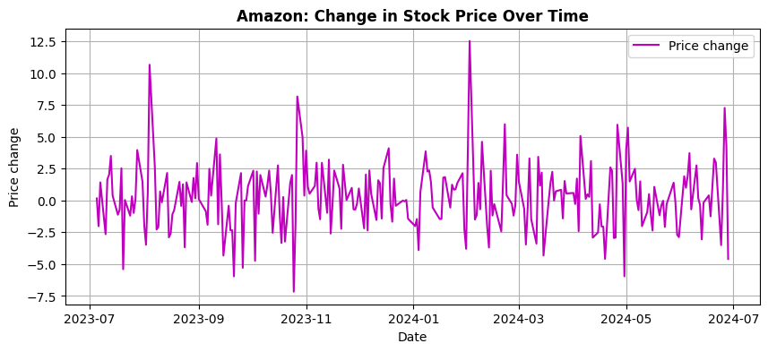

```python
plt.figure(figsize=(10, 4))
plt.plot(amazon_df.index, amazon_df['Stock price change'], label='Price change', color='m')
plt.title('Amazon: Change in Stock Price Over Time', fontweight='bold')
plt.xlabel('Date')
plt.ylabel('Price change')
plt.legend()
plt.grid(True)
plt.show()
```

**4) Visualizing the change in a stock’s volume being traded, over time**

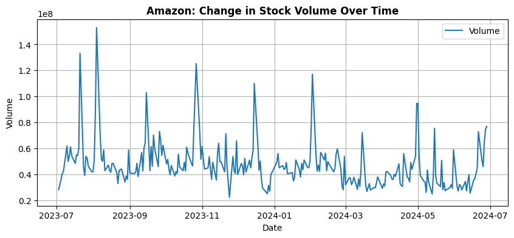

```python
plt.figure(figsize=(10, 4))
plt.plot(amazon_df.index, amazon_df['Volume'], label='Volume')
plt.title('Amazon: Change in Stock Volume Over Time', fontweight='bold')
plt.xlabel('Date')
plt.ylabel('Volume')
plt.legend()
plt.grid(True)
plt.show()
```

**5) Moving average of stocks**

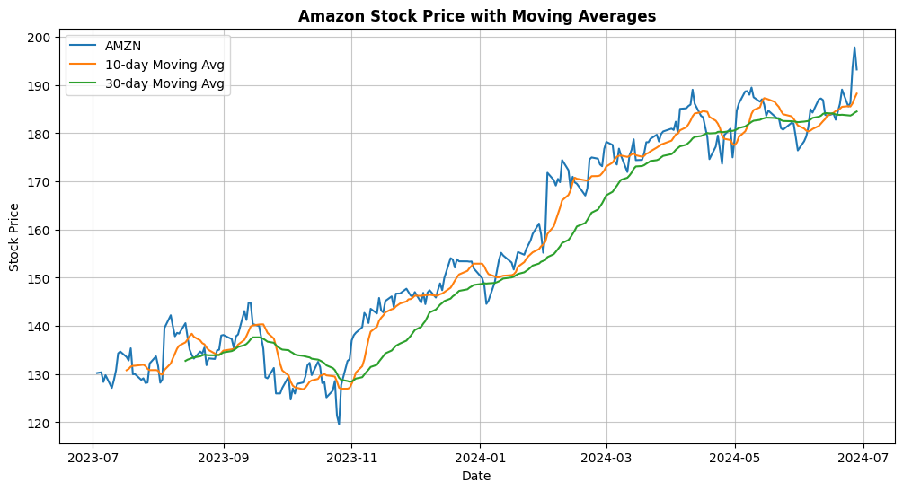

```python
amazon_df["10-day Moving Avg"] = amazon_df["Adj Close"].rolling(window=10).mean()
amazon_df["30-day Moving Avg"] = amazon_df["Adj Close"].rolling(window=30).mean()
plt.figure(figsize=(12,6))
plt.plot(amazon_df["Adj Close"], label="AMZN")
plt.plot(amazon_df["10-day Moving Avg"], label="10-day Moving Avg")
plt.plot(amazon_df["30-day Moving Avg"], label="30-day Moving Avg")
plt.legend()
plt.title('Amazon Stock Price with Moving Averages', fontweight='bold')
plt.xlabel('Date')
plt.ylabel('Stock Price')
plt.grid(True, alpha=0.7)
plt.show()
```

**6) Daily return average of the stock**

```python
amazon_df["Daily Return"] = amazon_df["Adj Close"].pct_change()
amazon_df
```

| Date | Open | High | Low | Close | Adj Close | Volume | Stock price change | 10-day Moving Avg | 30-day Moving Avg | Daily Return |
| --- | --- | --- | --- | --- | --- | --- | --- | --- | --- | --- |
| 2023-07-03 | 130.820007 | 131.850006 | 130.070007 | 130.220001 | 130.220001 | 28264800 | NaN | NaN | NaN | NaN |
| 2023-07-05 | 130.240005 | 131.399994 | 129.639999 | 130.380005 | 130.380005 | 35895400 | 0.160004 | NaN | NaN | 0.001229 |
| 2023-07-06 | 128.250000 | 128.729996 | 127.370003 | 128.360001 | 128.360001 | 40639900 | -2.020004 | NaN | NaN | -0.015493 |
| 2023-07-07 | 128.589996 | 130.970001 | 128.130005 | 129.779999 | 129.779999 | 41928700 | 1.419998 | NaN | NaN | 0.011063 |
| 2023-07-10 | 129.070007 | 129.279999 | 125.919998 | 127.129997 | 127.129997 | 61889300 | -2.650002 | NaN | NaN | -0.020419 |
| ... | ... | ... | ... | ... | ... | ... | ... | ... | ... | ... |
| 2024-06-24 | 189.330002 | 191.000000 | 185.330002 | 185.570007 | 185.570007 | 50610400 | -3.509995 | 185.629001 | 183.718001 | -0.018564 |
| 2024-06-25 | 186.809998 | 188.839996 | 185.419998 | 186.339996 | 186.339996 | 45898500 | 0.769989 | 185.557001 | 183.680001 | 0.004149 |
| 2024-06-26 | 186.919998 | 194.800003 | 186.259995 | 193.610001 | 193.610001 | 65103900 | 7.270004 | 186.195001 | 183.914667 | 0.039015 |
| 2024-06-27 | 195.009995 | 199.839996 | 194.199997 | 197.850006 | 197.850006 | 74397500 | 4.240005 | 187.291002 | 184.274001 | 0.021900 |
| 2024-06-28 | 197.729996 | 198.850006 | 192.500000 | 193.250000 | 193.250000 | 76930200 | -4.600006 | 188.233002 | 184.516000 | -0.023250 |

250 rows × 10 columns

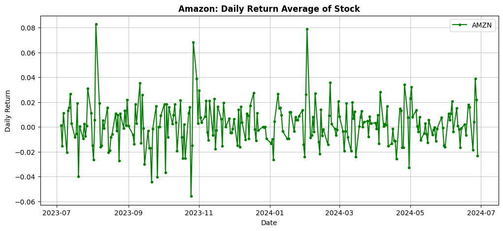

```python
plt.figure(figsize=(12, 5))
plt.plot(amazon_df.index,amazon_df['Daily Return'], label="AMZN", marker='.', linestyle='-', color='g')
plt.title('Amazon: Daily Return Average of Stock', fontweight='bold')
plt.xlabel('Date')
plt.ylabel('Daily Return')
plt.legend()
plt.grid(True, alpha=0.7)
plt.show()
```

**7) Checking the Trend based on Daily Return**

```python
amazon_df['Trend'] = np.where(amazon_df['Daily Return'] > 0, 'Up', np.where(amazon_df['Daily Return'] < 0, 'Down', 'Stable'))
amazon_df
```

| Date | Open | High | Low | Close | Adj Close | Volume | Stock price change | 10-day Moving Avg | 30-day Moving Avg | Daily Return | Trend |
| --- | --- | --- | --- | --- | --- | --- | --- | --- | --- | --- | --- |
| 2023-07-03 | 130.820007 | 131.850006 | 130.070007 | 130.220001 | 130.220001 | 28264800 | NaN | NaN | NaN | NaN | Stable |
| 2023-07-05 | 130.240005 | 131.399994 | 129.639999 | 130.380005 | 130.380005 | 35895400 | 0.160004 | NaN | NaN | 0.001229 | Up |
| 2023-07-06 | 128.250000 | 128.729996 | 127.370003 | 128.360001 | 128.360001 | 40639900 | -2.020004 | NaN | NaN | -0.015493 | Down |
| 2023-07-07 | 128.589996 | 130.970001 | 128.130005 | 129.779999 | 129.779999 | 41928700 | 1.419998 | NaN | NaN | 0.011063 | Up |
| 2023-07-10 | 129.070007 | 129.279999 | 125.919998 | 127.129997 | 127.129997 | 61889300 | -2.650002 | NaN | NaN | -0.020419 | Down |
| ... | ... | ... | ... | ... | ... | ... | ... | ... | ... | ... | ... |
| 2024-06-24 | 189.330002 | 191.000000 | 185.330002 | 185.570007 | 185.570007 | 50610400 | -3.509995 | 185.629001 | 183.718001 | -0.018564 | Down |
| 2024-06-25 | 186.809998 | 188.839996 | 185.419998 | 186.339996 | 186.339996 | 45898500 | 0.769989 | 185.557001 | 183.680001 | 0.004149 | Up |
| 2024-06-26 | 186.919998 | 194.800003 | 186.259995 | 193.610001 | 193.610001 | 65103900 | 7.270004 | 186.195001 | 183.914667 | 0.039015 | Up |
| 2024-06-27 | 195.009995 | 199.839996 | 194.199997 | 197.850006 | 197.850006 | 74397500 | 4.240005 | 187.291002 | 184.274001 | 0.021900 | Up |
| 2024-06-28 | 197.729996 | 198.850006 | 192.500000 | 193.250000 | 193.250000 | 76930200 | -4.600006 | 188.233002 | 184.516000 | -0.023250 | Down |

250 rows × 11 columns

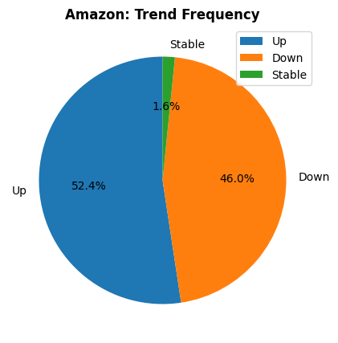

```python
plt.figure(figsize=(5, 5))
trend_counts = amazon_df['Trend'].value_counts()
plt.pie(trend_counts, labels=trend_counts.index, autopct='%1.1f%%', startangle=90)
plt.title('Amazon: Trend Frequency', fontweight='bold')
plt.legend()
plt.show()
```

# Combined Analysis of 4 stocks:

### Apple, Microsoft, Amazon, Google

```python
data = ['AAPL', 'GOOGL', 'MSFT', 'AMZN']
start_date = ('2023-07-01')
end_date = ('2024-07-01')
stocks_df = yf.download(data, start=start_date,end=end_date)
stocks_df
```

```
[*********************100%%**********************]  4 of 4 completed
```

| Date | Adj Close AAPL | Adj Close AMZN | Adj Close GOOGL | Adj Close MSFT | Close AAPL | Close AMZN | Close GOOGL | Close MSFT | High AAPL | High AMZN | ... | Low GOOGL | Low MSFT | Open AAPL | Open AMZN | Open GOOGL | Open MSFT | Volume AAPL | Volume AMZN | Volume GOOGL | Volume MSFT |
| --- | --- | --- | --- | --- | --- | --- | --- | --- | --- | --- | --- | --- | --- | --- | --- | --- | --- | --- | --- | --- | --- |
| 2023-07-03 | 191.443314 | 130.220001 | 119.762550 | 335.366516 | 192.460007 | 130.220001 | 119.900002 | 337.989990 | 193.880005 | 131.850006 | ... | 118.820000 | 336.570007 | 193.779999 | 130.820007 | 119.239998 | 339.190002 | 31458200 | 28264800 | 14467900 | 12508700 |
| 2023-07-05 | 190.319260 | 130.380005 | 121.610428 | 335.525299 | 191.330002 | 130.380005 | 121.750000 | 338.149994 | 192.979996 | 131.399994 | ... | 119.230003 | 334.730011 | 191.570007 | 130.240005 | 119.239998 | 335.089996 | 46920300 | 35895400 | 27584800 | 18172400 |
| 2023-07-06 | 190.796722 | 128.360001 | 119.972313 | 338.621063 | 191.809998 | 128.360001 | 120.110001 | 341.269989 | 192.020004 | 128.729996 | ... | 118.400002 | 335.500000 | 189.839996 | 128.250000 | 119.800003 | 337.299988 | 45094300 | 40639900 | 24745200 | 28161200 |
| 2023-07-07 | 189.672684 | 129.779999 | 119.343033 | 334.602509 | 190.679993 | 129.779999 | 119.480003 | 337.220001 | 192.669998 | 130.970001 | ... | 119.400002 | 337.000000 | 191.410004 | 128.589996 | 120.099998 | 339.320007 | 46778000 | 41928700 | 21692600 | 21185300 |
| 2023-07-10 | 187.613632 | 127.129997 | 116.316498 | 329.254333 | 188.610001 | 127.129997 | 116.449997 | 331.829987 | 189.990005 | 129.279999 | ... | 116.139999 | 327.589996 | 189.259995 | 129.070007 | 118.300003 | 334.600006 | 59922200 | 61889300 | 35315200 | 32791400 |
| ... | ... | ... | ... | ... | ... | ... | ... | ... | ... | ... | ... | ... | ... | ... | ... | ... | ... | ... | ... | ... | ... |
| 2024-06-24 | 208.139999 | 185.570007 | 179.220001 | 447.670013 | 208.139999 | 185.570007 | 179.220001 | 447.670013 | 212.699997 | 191.000000 | ... | 178.669998 | 446.410004 | 207.720001 | 189.330002 | 180.160004 | 449.799988 | 80727000 | 50610400 | 18298000 | 15913700 |
| 2024-06-25 | 209.070007 | 186.339996 | 184.029999 | 450.950012 | 209.070007 | 186.339996 | 184.029999 | 450.950012 | 211.380005 | 188.839996 | ... | 179.419998 | 446.750000 | 209.149994 | 186.809998 | 179.619995 | 448.250000 | 56713900 | 45898500 | 23235600 | 16747500 |
| 2024-06-26 | 213.250000 | 193.610001 | 183.880005 | 452.160004 | 213.250000 | 193.610001 | 183.880005 | 452.160004 | 214.860001 | 194.800003 | ... | 182.479996 | 448.190002 | 211.500000 | 186.919998 | 182.630005 | 449.000000 | 66213200 | 65103900 | 19839000 | 16507000 |
| 2024-06-27 | 214.100006 | 197.850006 | 185.410004 | 452.850006 | 214.100006 | 197.850006 | 185.410004 | 452.850006 | 215.740005 | 199.839996 | ... | 184.020004 | 451.769989 | 214.690002 | 195.009995 | 184.179993 | 452.179993 | 49772700 | 74397500 | 18848900 | 14806300 |
| 2024-06-28 | 210.619995 | 193.250000 | 182.149994 | 446.950012 | 210.619995 | 193.250000 | 182.149994 | 446.950012 | 216.070007 | 198.850006 | ... | 181.960007 | 446.410004 | 215.770004 | 197.729996 | 184.320007 | 453.070007 | 82542700 | 76930200 | 29156600 | 28362300 |

250 rows × 24 columns

```python
stocks_df.info()
```

```
<class 'pandas.core.frame.DataFrame'>
DatetimeIndex: 250 entries, 2023-07-03 to 2024-06-28
Data columns (total 24 columns):
 #   Column              Non-Null Count  Dtype
---  ------              --------------  -----
 0   (Adj Close, AAPL)   250 non-null    float64
 1   (Adj Close, AMZN)   250 non-null    float64
 2   (Adj Close, GOOGL)  250 non-null    float64
 3   (Adj Close, MSFT)   250 non-null    float64
 4   (Close, AAPL)       250 non-null    float64
 5   (Close, AMZN)       250 non-null    float64
 6   (Close, GOOGL)      250 non-null    float64
 7   (Close, MSFT)       250 non-null    float64
 8   (High, AAPL)        250 non-null    float64
 9   (High, AMZN)        250 non-null    float64
```

[output cut: 16 more lines]

#### Cleaning the dataset

```python
# To check if there is any null value in the loaded dataset
null_count = stocks_df.isnull().sum()

if null_count.any() > 0:
    print("There are ", null_count.sum(), " missing values in the dataframe. Take necessary actions!")
elif null_count.all() == 0:
    print("No null value in the dataframe")
```

```
No null value in the dataframe
```

```python
# Checking for duplicates:
duplicates = stocks_df.duplicated()

if duplicates.any():
    print("There are duplicates in the dataframe. Take necessary actions!")
else:
    print("No duplicates in the dataframe")
```

```
No duplicates in the dataframe
```

```python
stocks_df.isnull().sum()
```

```
Adj Close  AAPL     0
           AMZN     0
           GOOGL    0
           MSFT     0
Close      AAPL     0
           AMZN     0
           GOOGL    0
           MSFT     0
High       AAPL     0
           AMZN     0
           GOOGL    0
           MSFT     0
Low        AAPL     0
           AMZN     0
           GOOGL    0
           MSFT     0
Open       AAPL     0
           AMZN     0
           GOOGL    0
           MSFT     0
Volume     AAPL     0
           AMZN     0
           GOOGL    0
           MSFT     0
dtype: int64
```

#### Study of stocks price over time

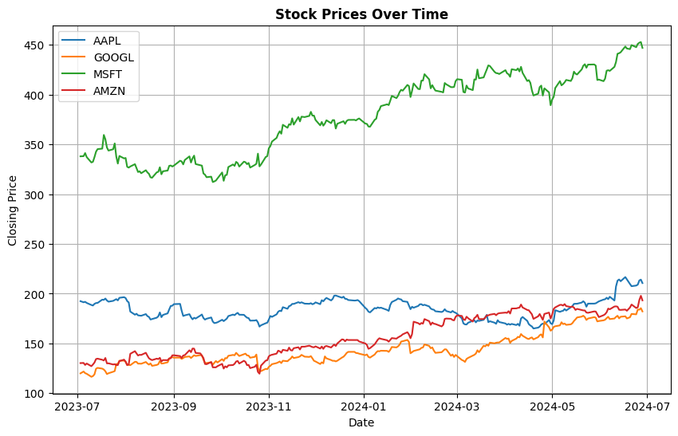

```python
plt.figure(figsize=(10, 6))
for stock in data:
    plt.plot(stocks_df['Close'][stock], label=stock)
plt.title('Stock Prices Over Time', fontweight='bold')
plt.xlabel('Date')
plt.ylabel('Closing Price')
plt.legend()
plt.grid(True)
plt.show()
```

#### Change in a stock’s volume being traded, over time

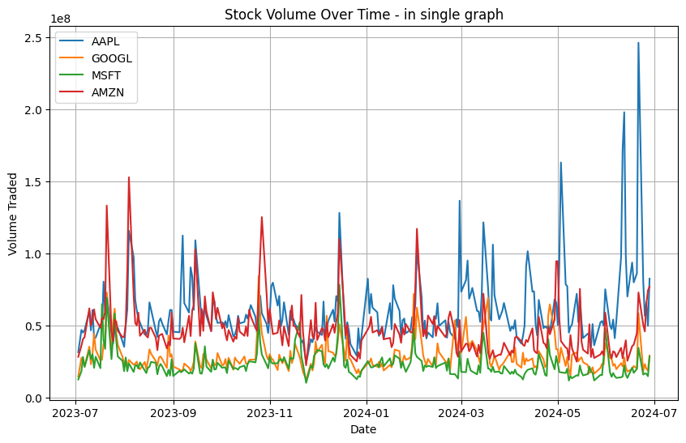

```python
plt.figure(figsize=(10, 6))
for stock in data:
    plt.plot(stocks_df['Volume'][stock], label=stock)
plt.title('Stock Volume Over Time - in single graph')
plt.xlabel('Date')
plt.ylabel('Volume Traded')
plt.legend()
plt.grid(True)
plt.show()
```

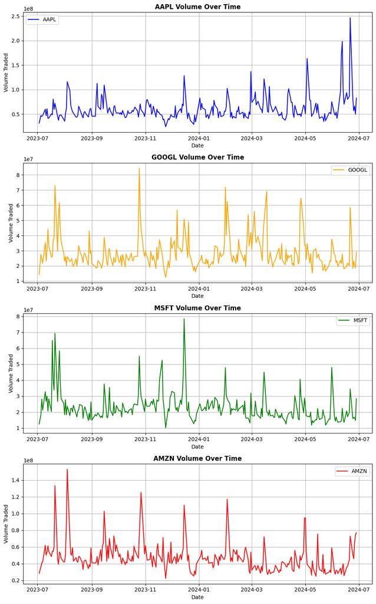

```python
colors = ['blue', 'orange', 'green', 'red']  # List of colors for each stock
n_stocks = len(data)

fig, axs = plt.subplots(n_stocks, 1, figsize=(10, 4 * n_stocks))

for i, (stock, color) in enumerate(zip(data, colors)):
    axs[i].plot(stocks_df.index, stocks_df['Volume'][stock], label=stock, color=color)
    axs[i].set_title(f'{stock} Volume Over Time', fontweight='bold')
    axs[i].set_xlabel('Date')
    axs[i].set_ylabel('Volume Traded')
    axs[i].legend()
    axs[i].grid(True)

plt.tight_layout()
plt.show()
```

#### Moving Average of various stocks

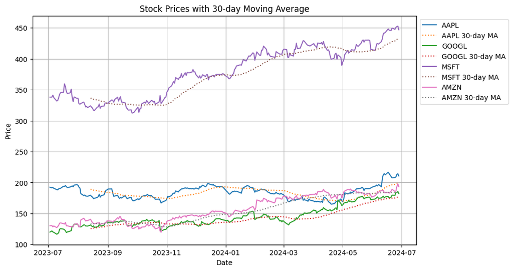

```python
plt.figure(figsize=(10, 6))
for stock in data:
    plt.plot(stocks_df['Close'][stock], label=stock)
    plt.plot(stocks_df['Close'][stock].rolling(window=30).mean(), label=f'{stock} 30-day MA', linestyle=':')

plt.title('Stock Prices with 30-day Moving Average')
plt.xlabel('Date')
plt.ylabel('Price')
plt.legend(bbox_to_anchor=(1,1))
plt.grid(True)
plt.show()
```

#### Daily Return Average of a stock

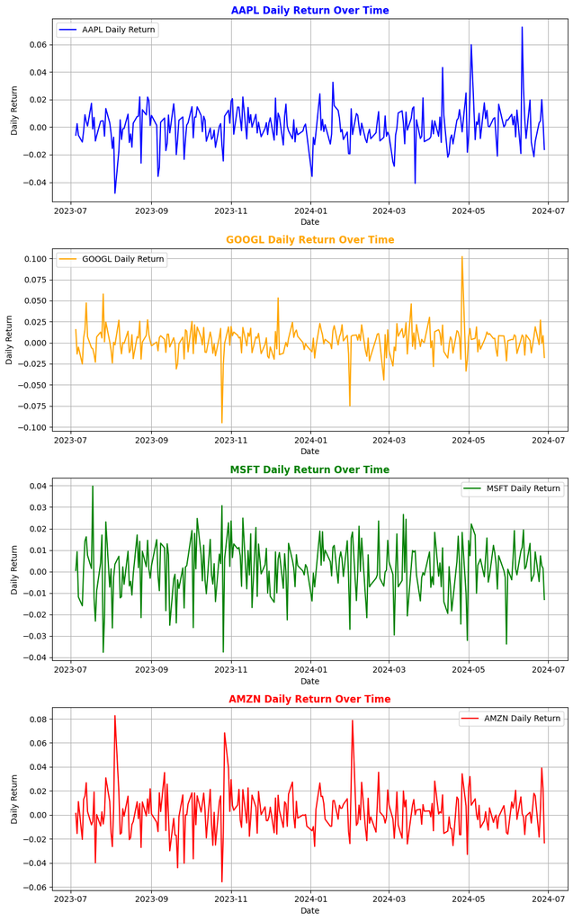

```
Maximum Daily Return for AAPL: 0.07264912559045644
Maximum Daily Return for GOOGL: 0.10224357018103958
Maximum Daily Return for MSFT: 0.039799782520444804
Maximum Daily Return for AMZN: 0.08269337801006271
```

```python
colors = ['blue', 'orange', 'green', 'red']

# Calculate daily returns for each stock
for stock in data:
    stocks_df[f'{stock}_Daily_Return'] = stocks_df['Close'][stock].pct_change()

# Create subplots
fig, axs = plt.subplots(len(data), 1, figsize=(10, 4* len(data)))

# Plot daily returns for each stock in a separate subplot
for i, (stock, color) in enumerate(zip(data, colors)):
    axs[i].plot(stocks_df.index, stocks_df[f'{stock}_Daily_Return'], label=f'{stock} Daily Return', color=color)
    axs[i].set_title(f'{stock} Daily Return Over Time', color=color, fontweight='bold')
    axs[i].set_xlabel('Date')
    axs[i].set_ylabel('Daily Return')
    axs[i].legend()
    axs[i].grid(True)

plt.tight_layout()
plt.show()

# Print maximum daily return for each stock
for stock in data:
    max_return = stocks_df[f'{stock}_Daily_Return'].max()
    print(f'Maximum Daily Return for {stock}: {max_return}')
```

#### Study of Trend based on the values of Daily Return

```python
for stock in data:
    stocks_df[f'{stock}_Trend'] = ['Up' if x > 0 else 'Down' if x < 0 else 'Stable' for x in stocks_df[f'{stock}_Daily_Return']]

stocks_df
```

| Date | Adj Close AAPL | Adj Close AMZN | Adj Close GOOGL | Adj Close MSFT | Close AAPL | Close AMZN | Close GOOGL | Close MSFT | High AAPL | High AMZN | ... | Volume GOOGL | Volume MSFT | AAPL_Daily_Return | GOOGL_Daily_Return | MSFT_Daily_Return | AMZN_Daily_Return | AAPL_Trend | GOOGL_Trend | MSFT_Trend | AMZN_Trend |
| --- | --- | --- | --- | --- | --- | --- | --- | --- | --- | --- | --- | --- | --- | --- | --- | --- | --- | --- | --- | --- | --- |
| 2023-07-03 | 191.443314 | 130.220001 | 119.762550 | 335.366516 | 192.460007 | 130.220001 | 119.900002 | 337.989990 | 193.880005 | 131.850006 | ... | 14467900 | 12508700 | NaN | NaN | NaN | NaN | Stable | Stable | Stable | Stable |
| 2023-07-05 | 190.319260 | 130.380005 | 121.610428 | 335.525299 | 191.330002 | 130.380005 | 121.750000 | 338.149994 | 192.979996 | 131.399994 | ... | 27584800 | 18172400 | -0.005871 | 0.015430 | 0.000473 | 0.001229 | Down | Up | Up | Up |
| 2023-07-06 | 190.796722 | 128.360001 | 119.972313 | 338.621063 | 191.809998 | 128.360001 | 120.110001 | 341.269989 | 192.020004 | 128.729996 | ... | 24745200 | 28161200 | 0.002509 | -0.013470 | 0.009227 | -0.015493 | Up | Down | Up | Down |
| 2023-07-07 | 189.672684 | 129.779999 | 119.343033 | 334.602509 | 190.679993 | 129.779999 | 119.480003 | 337.220001 | 192.669998 | 130.970001 | ... | 21692600 | 21185300 | -0.005891 | -0.005245 | -0.011867 | 0.011063 | Down | Down | Down | Up |
| 2023-07-10 | 187.613632 | 127.129997 | 116.316498 | 329.254333 | 188.610001 | 127.129997 | 116.449997 | 331.829987 | 189.990005 | 129.279999 | ... | 35315200 | 32791400 | -0.010856 | -0.025360 | -0.015984 | -0.020419 | Down | Down | Down | Down |
| ... | ... | ... | ... | ... | ... | ... | ... | ... | ... | ... | ... | ... | ... | ... | ... | ... | ... | ... | ... | ... | ... |
| 2024-06-24 | 208.139999 | 185.570007 | 179.220001 | 447.670013 | 208.139999 | 185.570007 | 179.220001 | 447.670013 | 212.699997 | 191.000000 | ... | 18298000 | 15913700 | 0.003133 | -0.002282 | -0.004691 | -0.018564 | Up | Down | Down | Down |
| 2024-06-25 | 209.070007 | 186.339996 | 184.029999 | 450.950012 | 209.070007 | 186.339996 | 184.029999 | 450.950012 | 211.380005 | 188.839996 | ... | 23235600 | 16747500 | 0.004468 | 0.026839 | 0.007327 | 0.004149 | Up | Up | Up | Up |
| 2024-06-26 | 213.250000 | 193.610001 | 183.880005 | 452.160004 | 213.250000 | 193.610001 | 183.880005 | 452.160004 | 214.860001 | 194.800003 | ... | 19839000 | 16507000 | 0.019993 | -0.000815 | 0.002683 | 0.039015 | Up | Down | Up | Up |
| 2024-06-27 | 214.100006 | 197.850006 | 185.410004 | 452.850006 | 214.100006 | 197.850006 | 185.410004 | 452.850006 | 215.740005 | 199.839996 | ... | 18848900 | 14806300 | 0.003986 | 0.008321 | 0.001526 | 0.021900 | Up | Up | Up | Up |
| 2024-06-28 | 210.619995 | 193.250000 | 182.149994 | 446.950012 | 210.619995 | 193.250000 | 182.149994 | 446.950012 | 216.070007 | 198.850006 | ... | 29156600 | 28362300 | -0.016254 | -0.017583 | -0.013029 | -0.023250 | Down | Down | Down | Down |

250 rows × 32 columns

#### Visualizing Trend frequency

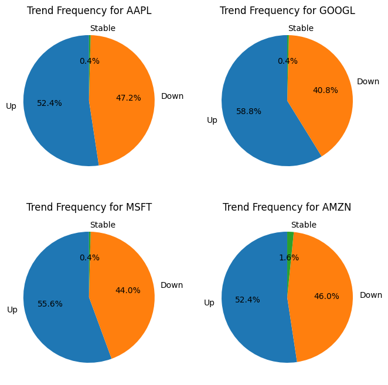

```python
fig, axs = plt.subplots(2, 2, figsize=(8,8))

# Flatten the 2x2 array of axes for easier iteration
axs = axs.flatten()

for i, stock in enumerate(data):
    trend_counts = stocks_df[f'{stock}_Trend'].value_counts()
    axs[i].pie(trend_counts, labels=trend_counts.index, autopct='%1.1f%%', startangle=90)
    axs[i].set_title(f'Trend Frequency for {stock}')

#plt.tight_layout()
plt.show()
```

#### Correlation between the daily returns of different stocks

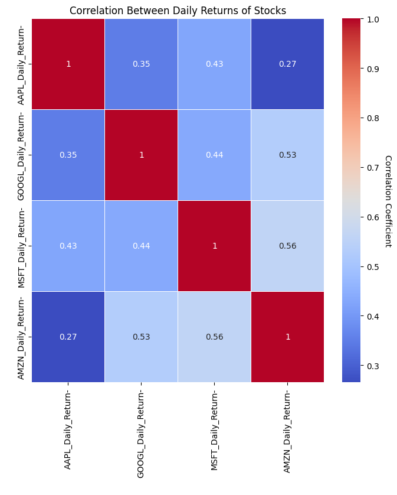

```python
daily_returns = stocks_df[[f'{stock}_Daily_Return' for stock in data]]
correlation_matrix = daily_returns.corr()
daily_returns = stocks_df[[f'{stock}_Daily_Return' for stock in data]]
correlation_matrix = daily_returns.corr()

plt.figure(figsize=(8, 8))
heatmap = sns.heatmap(correlation_matrix, annot=True, cmap='coolwarm', linewidths=.5)

# Add a label to the colorbar
cbar = heatmap.collections[0].colorbar
cbar.set_label('Correlation Coefficient', rotation=270, labelpad=15)

plt.title('Correlation Between Daily Returns of Stocks')
plt.xlabel(' ')
plt.ylabel(' ')
plt.show()
```

### - - - - - - - - - - - - - - - - - - - - - - - - - - end - - - - - - - - - - - - - - - - - - - - - - - - - -